# APS II - Microeconomia IV

João Casella, Pedro Marino, Victor Alves

2022-09-16

```r
library(tidyverse)
library(magrittr)
library(gridExtra)
library(ggthemes)
library(questionr)
library(survey)
library(skimr)
library(VGAM)
library(margins)
library(ROCit)
library(lmtest)
library(ResourceSelection)
library(stargazer)
```

# Manipulação da base de dados

```r
wvs <- read.csv('W7.csv') %>%
select( # selecionando as variáveis de interesse
  Q1, Q4, Q5, Q46, Q49, Q37, Q32,
  Q28, Q190, Q143,
  W_WEIGHT, Q267,
  Q260, Q262, Q273, Q274, Q275, Q275R, Q279,
  Q288, Q288R, H_URBRURAL, Q290, B_COUNTRY_ALPHA
) %>%
mutate_if( # transformando negativo em NA
  is.numeric, function(x) {x[x < 0] <- NA; x}
  ) %>%
filter( # filtrando NAs
  !is.na(Q1),
  !is.na(Q4),
  !is.na(Q5),
  !is.na(Q46),
  !is.na(Q49),
  !is.na(Q37),
  !is.na(Q32),
  !is.na(Q28),
  !is.na(Q190),
  !is.na(Q143),
  !is.na(W_WEIGHT),
  !is.na(Q267),
  !is.na(Q260),
  !is.na(Q262),
  !is.na(Q273),
  !is.na(Q274),
  !is.na(Q275),
  !is.na(Q275R),
  !is.na(Q279),
  !is.na(Q288),
  !is.na(Q288R),
  !is.na(Q290),
  !is.na(H_URBRURAL)
) %>%
rename(
  family_important = Q1,
  politics_important = Q4,
  work_not_important = Q5,
  duty_have_children = Q37,
  happy_as_housewife = Q32,
  satisfaction = Q49,
  children_suffers_work_mom = Q28,
  not_acceptable_beat_children = Q190,
  worries_education_children = Q143,
  country_code = B_COUNTRY_ALPHA,
  sample_weight = W_WEIGHT,
  happy = Q46,
  mother_country = Q267,
  sex = Q260,
  age = Q262,
  marital_status = Q273,
  children = Q274,
  education_scale = Q275,
  education_level = Q275R,
  employment_status = Q279,
  income_decile = Q288,
  income_level = Q288R,
  rural_area = H_URBRURAL,
  ethnic_group = Q290
) %>%
mutate(
  family_important = case_when(
    family_important <= 2 ~ 1,
    TRUE ~ 0), # considera família importante ou não
  politics_important = case_when(
    politics_important <= 2 ~ 1,
    TRUE ~ 0), # considera política importante ou não
  work_not_important = case_when(
    work_not_important > 2 ~ 1,
    TRUE ~ 0), # considera trabalho importante ou não
  happy = case_when(
    happy <= 2 ~ 1,
    TRUE ~ 0), # se considera feliz ou não
  duty_have_children = case_when(
    duty_have_children <= 2 ~ 1,
    TRUE ~ 0), # concorda com dever em ter crianças ou não
  happy_as_housewife = case_when(
    happy_as_housewife <= 2 ~ 1,
    TRUE ~ 0), # concorda em ser housewife ou não
  children_suffers_work_mom = case_when(
    children_suffers_work_mom <= 2 ~ 1,
    TRUE ~ 0), # concorda que a criança sofre com a mãe trabalhando
  not_acceptable_beat_children = case_when(
    not_acceptable_beat_children == 1 ~ 1,
    TRUE ~ 0), #  não concorda em bater em crianças ou sim
  worries_education_children = case_when(
    worries_education_children <= 2 ~ 1,
    TRUE ~ 0), # se preocupa em não dar boa eduação para crianças
  age = case_when(
    age >= 0 & age <= 17 ~ 'Abaixo de 18',
    age >= 18 & age <= 30 ~ '18 - 30',
    age >= 31 & age <= 40 ~ '31 - 40',
    age >= 41 & age <= 50 ~ '41 - 50',
    age >= 61 & age <= 70 ~ '61 - 70',
    TRUE ~ 'Acima de 70'), # faixa de idade
  sex = case_when(
    sex == 1 ~ 'Masculino',
    TRUE ~ 'Feminino'
  ),
  education_level = case_when(
    education_level == 1 ~ 'Baixo',
    education_level == 2 ~ 'Médio',
    TRUE ~ 'Alto'), # nível educacional
  employment_status = case_when(
    employment_status == 1 ~ 'Integral',
    employment_status == 2 ~ 'Parcial',
    employment_status == 3 ~ 'Autônomo',
    employment_status == 4 ~ 'Aposentado',
    employment_status == 5 ~ 'Do lar',
    employment_status %in% c(6,7) ~ 'Desempregado',
    TRUE ~ 'Outros'),
  income_quantile = case_when(
    income_decile <= 2 ~ 1,
    income_decile >= 3 & income_decile <= 4 ~ 2,
    income_decile >= 5 & income_decile <= 6 ~ 3,
    TRUE ~ 4), # quantil de renda com base no decil
  marital_status = case_when(
    marital_status %in% c(1:2) ~ 'Casada ou morando junto',
    marital_status %in% c(3:5) ~ 'Divorciada ou viúvia',
    TRUE ~ 'Solteira'), # status civil
  married = case_when(
    marital_status == 'Casada ou morando junto' ~ 1,
    TRUE ~ 0
  ),
  number_children = case_when(
    children == 0 ~ 'Sem filhos',
    children == 1 ~ 'Um filho',
    children == 2 ~ 'Dois filhos',
    TRUE ~ 'Três ou mais filhos'),
  proper_level = family_important + work_not_important + duty_have_children + happy_as_housewife +
    children_suffers_work_mom + not_acceptable_beat_children + worries_education_children + married,
  conformity = case_when(
    proper_level >= 5 ~ 1,
    TRUE ~ 0)
  ) %>%
mutate( # transformando todas as colunas em categóricas
  family_important = as_factor(family_important),
  politics_important = as_factor(politics_important),
  work_not_important = as_factor(work_not_important),
  duty_have_children = as_factor(duty_have_children),
  happy_as_housewife = as_factor(happy_as_housewife),
  satisfaction = as_factor(satisfaction),
  children_suffers_work_mom = as_factor(children_suffers_work_mom),
  not_acceptable_beat_children = as_factor(not_acceptable_beat_children),
  worries_education_children = as_factor(worries_education_children),
  country_code = as_factor(country_code),
  happy = as_factor(happy),
  mother_country = as_factor(mother_country),
  sex = as_factor(sex),
  age = as_factor(age),
  marital_status = as_factor(marital_status),
  married = as_factor(married),
  number_children = as_factor(number_children),
  education_scale = as_factor(education_scale),
  education_level = as_factor(education_level),
  employment_status = as_factor(employment_status),
  income_decile = as_factor(income_decile),
  income_level = as_factor(income_level),
  income_quantile = as_factor(income_quantile),
  rural_area = as_factor(rural_area),
  ethnic_group = as_factor(ethnic_group),
  conformity = as_factor(conformity)
)


wvs$country <- countrycode::countrycode(
  wvs$country_code, # criando variável para país
  origin = 'iso3c',
  destination = 'country.name')

svy <- svydesign(id = ~1, weights = wvs$sample_weight, data = wvs) # aplicando o peso amostral

wvs_mulheres <- wvs %>%
  filter(sex == 'Feminino') # filtrando somente mulheres

svy_mulheres <- svydesign(id = ~1, weights = wvs_mulheres$sample_weight, data = wvs_mulheres) # aplicando o peso amostral
```

# Descritivas

Felicidade entre mulheres

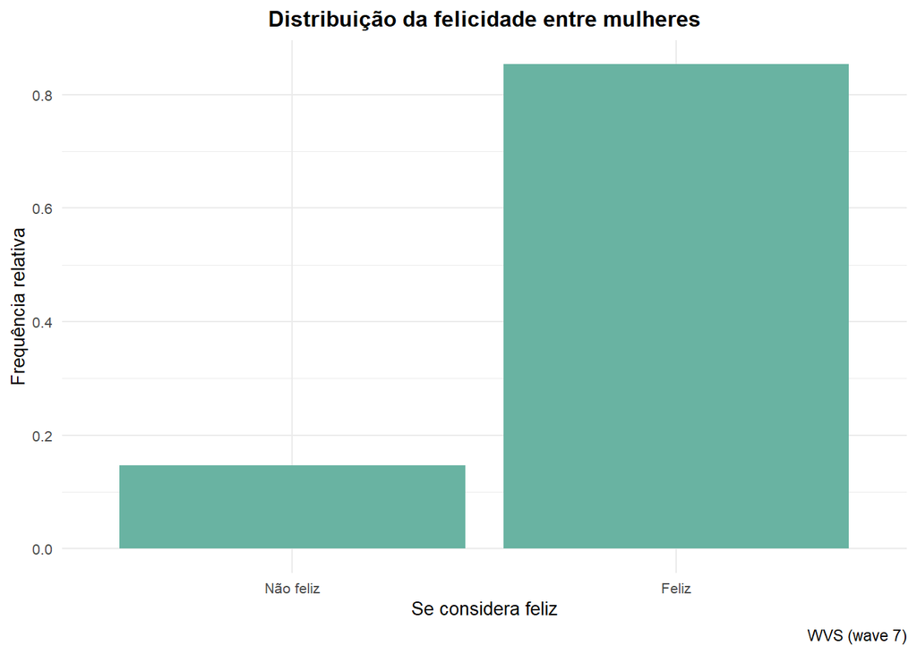

```r
svy_mulheres %>%
  ggsurvey() +
  geom_bar(aes(x = happy, y= ..count.. / sum(..count..)), fill = '#69b3a2') +
  theme_minimal() +
  labs(x = 'Se considera feliz',
       y = 'Frequência relativa',
       title = 'Distribuição da felicidade entre mulheres',
       caption = 'WVS (wave 7)') +
  theme(plot.title=element_text(size=12, face="bold", hjust = 0.5),
        legend.text=element_text(size=8),
        axis.text=element_text(size=8),
        axis.title = element_text(size = 10),
        legend.title = element_text(size = 10)) +
  scale_x_discrete(labels = c('Não feliz', 'Feliz'))
```

Distribuição da felicidade entre mulheres casadas e solteiras

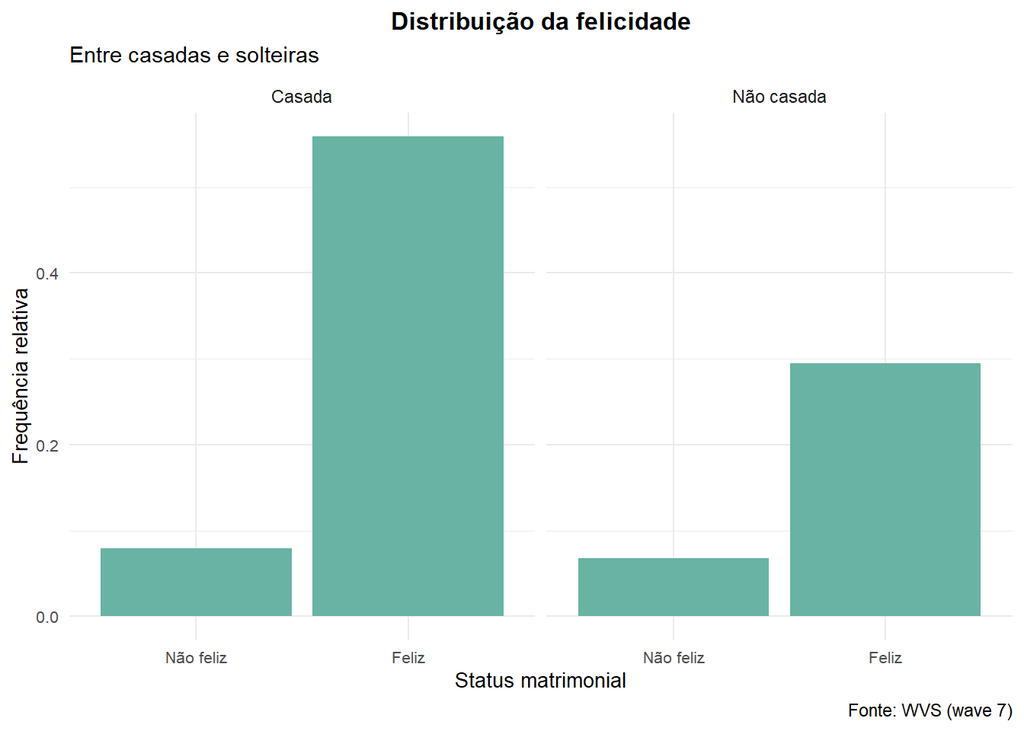

```r
wvs_mulheres2 <- wvs_mulheres %>%
  mutate(
    married = case_when(
      married == 1 ~ 'Casada',
      TRUE ~ 'Não casada'
    )
  )

svy_mulheres2 <- svydesign(id = ~1,
                           weights = wvs_mulheres2$sample_weight,
                           data = wvs_mulheres2)
svy_mulheres2 %>%
  ggsurvey() +
  geom_bar(aes(x = happy, y= ..count.. / sum(..count..)), fill = '#69b3a2') +
  theme_minimal() +
  labs(x = 'Status matrimonial',
       y = 'Frequência relativa',
       title = 'Distribuição da felicidade',
       subtitle = 'Entre casadas e solteiras',
       caption = 'Fonte: WVS (wave 7)') +
  theme(plot.title=element_text(size=12, face="bold", hjust = 0.5),
        legend.text=element_text(size=8),
        axis.text=element_text(size=8),
        axis.title = element_text(size = 10),
        legend.title = element_text(size = 10)) +
  scale_x_discrete(labels = c('Não feliz', 'Feliz'))+
  facet_grid(cols = vars(married))
```

Distribuição da felicidade entre mulheres com e sem filhos

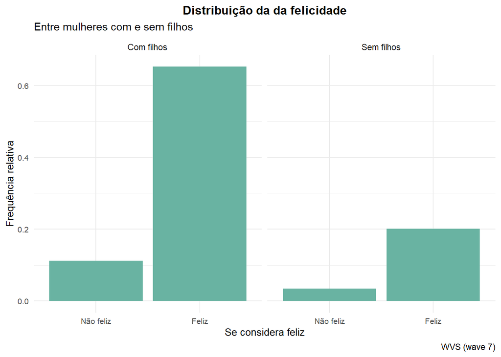

```r
wvs_mulheres0 <- wvs_mulheres %>%
  mutate(
    children = case_when(
      children == 0 ~ 'Sem filhos',
      TRUE ~ 'Com filhos'))

svy_mulheres0 <- svydesign(id = ~1,
                           weights = wvs_mulheres0$sample_weight,
                           data = wvs_mulheres0)
svy_mulheres0 %>%
  ggsurvey() +
  geom_bar(aes(x = happy, y= ..count.. / sum(..count..)), fill = '#69b3a2') +
  theme_minimal() +
  labs(x = 'Se considera feliz',
       y = 'Frequência relativa',
       title = 'Distribuição da da felicidade',
       subtitle = 'Entre mulheres com e sem filhos',
       caption = 'WVS (wave 7)') +
  theme(plot.title=element_text(size=12, face="bold", hjust = 0.5),
        legend.text=element_text(size=8),
        axis.text=element_text(size=8),
        axis.title = element_text(size = 10),
        legend.title = element_text(size = 10)) +
  scale_x_discrete(labels = c('Não feliz', 'Feliz'))+
  facet_grid(cols = vars(children))
```

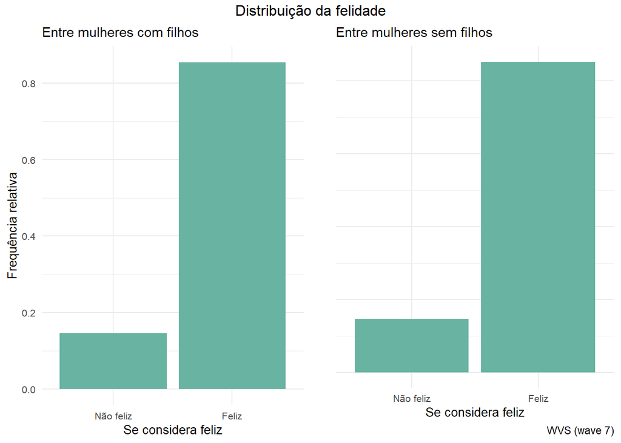

```r
wvs_mulheres_filhos <- wvs_mulheres %>%
  filter(children != 0)
svy_mulheres_filhos <- svydesign(id = ~1, weights = wvs_mulheres_filhos$sample_weight,
                                 data = wvs_mulheres_filhos)

wvs_mulheres_sem_filhos <- wvs_mulheres %>%
  filter(children == 0)
svy_mulheres_sem_filhos <- svydesign(id = ~1, weights = wvs_mulheres_sem_filhos$sample_weight,
                                     data = wvs_mulheres_sem_filhos)

a <-  svy_mulheres_filhos %>%
  ggsurvey() +
  geom_bar(aes(x = happy, y= ..count.. / sum(..count..)), fill = '#69b3a2') +
  theme_minimal() +
  labs(x = 'Se considera feliz',
       y = 'Frequência relativa',
       subtitle = 'Entre mulheres com filhos') +
  theme(plot.title=element_text(size=12, face="bold", hjust = 0.5),
        legend.text=element_text(size=8),
        axis.text=element_text(size=8),
        axis.title = element_text(size = 10),
        legend.title = element_text(size = 10)) +
  scale_x_discrete(labels = c('Não feliz', 'Feliz'))


b <- svy_mulheres_sem_filhos %>%
  ggsurvey() +
  geom_bar(aes(x = happy, y= ..count.. / sum(..count..)), fill = '#69b3a2') +
  theme_minimal() +
  labs(x = 'Se considera feliz',
       y = '',
       subtitle = 'Entre mulheres sem filhos',
       caption = 'WVS (wave 7)') +
  theme(plot.title=element_text(size=12, face="bold", hjust = 0.5),
        legend.text=element_text(size=8),
        axis.text.y=element_blank(),
        axis.ticks.y=element_blank(),
        axis.text=element_text(size=8),
        axis.title = element_text(size = 10),
        legend.title = element_text(size = 10)) +
  scale_x_discrete(labels = c('Não feliz', 'Feliz'))

grid.arrange(arrangeGrob(a,b, ncol = 2), top = 'Distribuição da felidade')
```

[figure not shown]

```r
wvs_mulheres_casadas <- wvs_mulheres %>%
  filter(married != 0)
svy_mulheres_casadas <- svydesign(id = ~1, weights = wvs_mulheres_casadas$sample_weight,
                                 data = wvs_mulheres_casadas)

wvs_mulheres_nao_casadas <- wvs_mulheres %>%
  filter(married == 0)
svy_mulheres_nao_casadas <- svydesign(id = ~1, weights = wvs_mulheres_nao_casadas$sample_weight,
                                     data = wvs_mulheres_nao_casadas)

a <-  svy_mulheres_casadas %>%
  ggsurvey() +
  geom_bar(aes(x = happy, y= ..count.. / sum(..count..)), fill = '#69b3a2') +
  theme_minimal() +
  labs(x = 'Se considera feliz',
       y = 'Frequência relativa',
       subtitle = 'Entre mulheres casadas') +
  theme(plot.title=element_text(size=12, face="bold", hjust = 0.5),
        legend.text=element_text(size=8),
        axis.text=element_text(size=8),
        axis.title = element_text(size = 10),
        legend.title = element_text(size = 10)) +
  scale_x_discrete(labels = c('Não feliz', 'Feliz'))


b <- svy_mulheres_casadas %>%
  ggsurvey() +
  geom_bar(aes(x = happy, y= ..count.. / sum(..count..)), fill = '#69b3a2') +
  theme_minimal() +
  labs(x = 'Se considera feliz',
       y = '',
       subtitle = 'Entre mulheres solteiras',
       caption = 'WVS (wave 7)') +
  theme(plot.title=element_text(size=12, face="bold", hjust = 0.5),
        legend.text=element_text(size=8),
        axis.text.y=element_blank(),
        axis.ticks.y=element_blank(),
        axis.text=element_text(size=8),
        axis.title = element_text(size = 10),
        legend.title = element_text(size = 10)) +
  scale_x_discrete(labels = c('Não feliz', 'Feliz'))

grid.arrange(arrangeGrob(a,b, ncol = 2), top = 'Distribuição da felidade')
```

Distribuição da quantidade de filhos

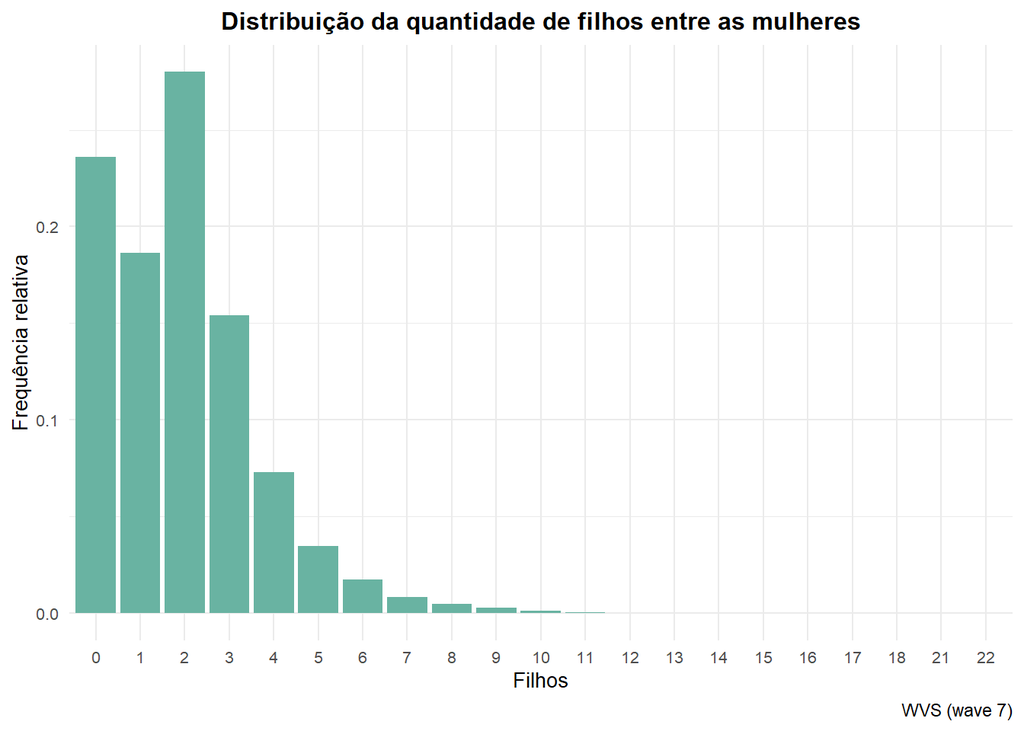

```r
svy_mulheres %>%
  ggsurvey() +
  geom_bar(aes(x = as_factor(children), y= ..count.. / sum(..count..)), fill = '#69b3a2') +
  theme_minimal() +
  labs(x = 'Filhos',
       y = 'Frequência relativa',
       title = 'Distribuição da quantidade de filhos entre as mulheres',
       caption = 'WVS (wave 7)') +
  theme(plot.title=element_text(size=12, face="bold", hjust = 0.5),
        legend.text=element_text(size=8),
        axis.text=element_text(size=8),
        axis.title = element_text(size = 10),
        legend.title = element_text(size = 10))
```

Distribuição da importância da família entre as mulheres

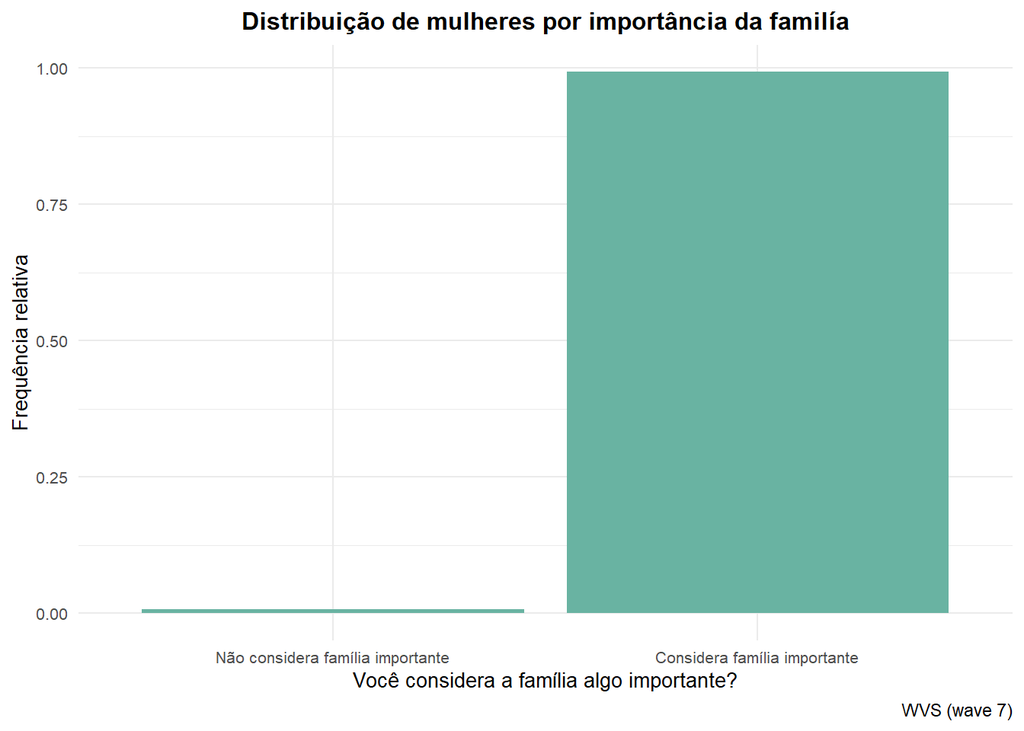

```r
svy_mulheres %>%
  ggsurvey() +
  geom_bar(aes(x = family_important, y= ..count.. / sum(..count..)), fill = '#69b3a2') +
  theme_minimal() +
  labs(x = 'Você considera a família algo importante?',
       y = 'Frequência relativa',
       title = 'Distribuição de mulheres por importância da familía',
       caption = 'WVS (wave 7)') +
  theme(plot.title=element_text(size=12, face="bold", hjust = 0.5),
        legend.text=element_text(size=8),
        axis.text=element_text(size=8),
        axis.title = element_text(size = 10),
        legend.title = element_text(size = 10))+
  scale_x_discrete(labels = c('Não considera família importante', 'Considera família importante'))
```

Distribuição do dever de ter filhos

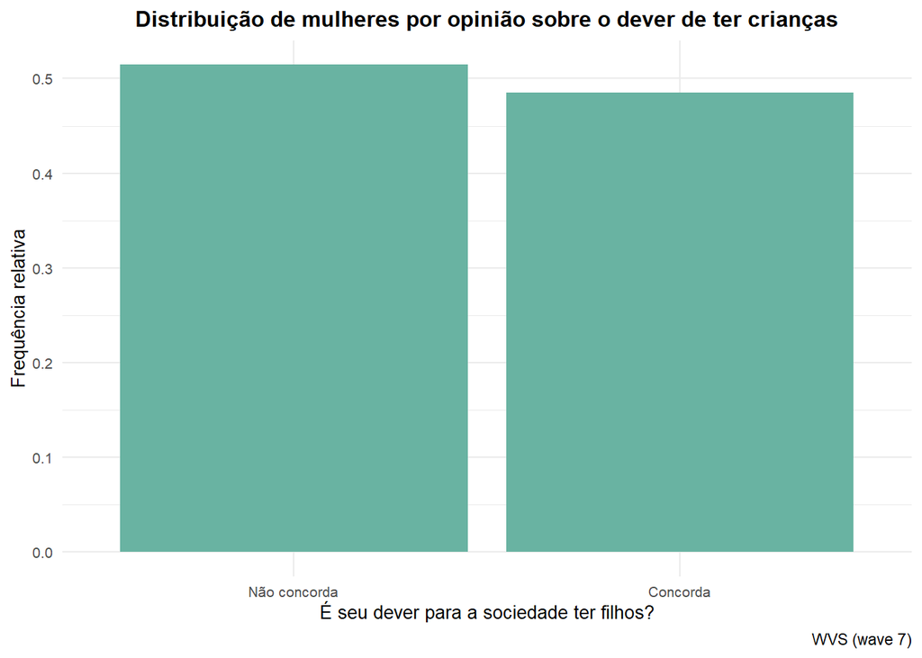

```r
svy_mulheres %>%
  ggsurvey() +
  geom_bar(aes(x = duty_have_children, y= ..count.. / sum(..count..)), fill = '#69b3a2') +
  theme_minimal() +
  labs(x = 'É seu dever para a sociedade ter filhos?',
       y = 'Frequência relativa',
       title = 'Distribuição de mulheres por opinião sobre o dever de ter crianças',
       caption = 'WVS (wave 7)') +
  theme(plot.title=element_text(size=12, face="bold", hjust = 0.5),
        legend.text=element_text(size=8),
        axis.text=element_text(size=8),
        axis.title = element_text(size = 10),
        legend.title = element_text(size = 10))+
  scale_x_discrete(labels = c('Não concorda', 'Concorda'))
```

Distribuição sobre trabalhar em casa ou ser dona de casa

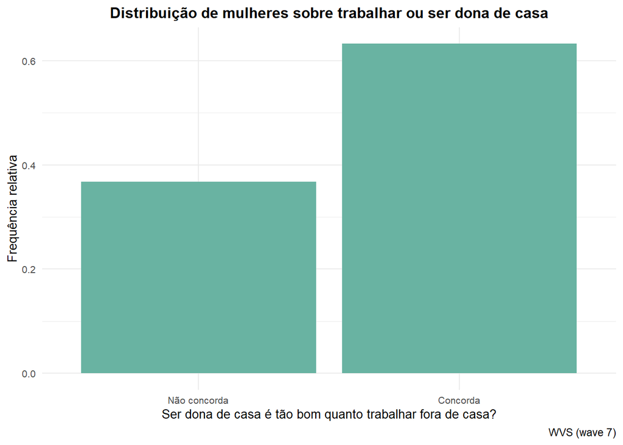

```r
svy_mulheres %>%
  ggsurvey() +
  geom_bar(aes(x = happy_as_housewife, y= ..count.. / sum(..count..)), fill = '#69b3a2') +
  theme_minimal() +
  labs(x = 'Ser dona de casa é tão bom quanto trabalhar fora de casa?',
       y = 'Frequência relativa',
       title = 'Distribuição de mulheres sobre trabalhar ou ser dona de casa',
       caption = 'WVS (wave 7)') +
  theme(plot.title=element_text(size=12, face="bold", hjust = 0.5),
        legend.text=element_text(size=8),
        axis.text=element_text(size=8),
        axis.title = element_text(size = 10),
        legend.title = element_text(size = 10))+
  scale_x_discrete(labels = c('Não concorda', 'Concorda'))
```

Distribuição da opinião sobre sofrimente de crianças que a mãe trabalha

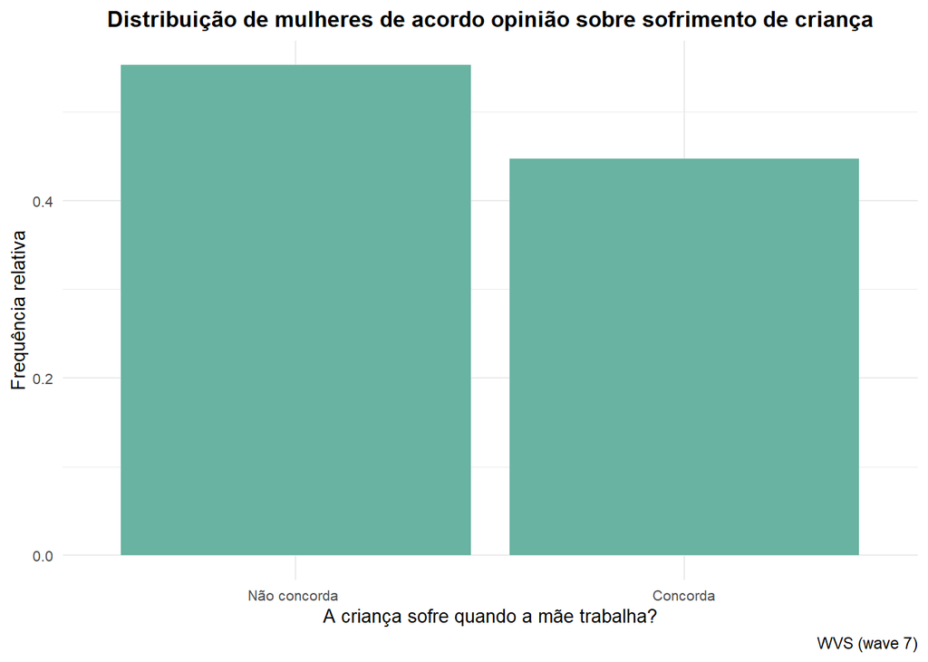

```r
svy_mulheres %>%
  ggsurvey() +
  geom_bar(aes(x = children_suffers_work_mom, y= ..count.. / sum(..count..)), fill = '#69b3a2') +
  theme_minimal() +
  labs(x = 'A criança sofre quando a mãe trabalha?',
       y = 'Frequência relativa',
       title = 'Distribuição de mulheres de acordo opinião sobre sofrimento de criança',
       caption = 'WVS (wave 7)') +
  theme(plot.title=element_text(size=12, face="bold", hjust = 0.5),
        legend.text=element_text(size=8),
        axis.text=element_text(size=8),
        axis.title = element_text(size = 10),
        legend.title = element_text(size = 10))+
  scale_x_discrete(labels = c('Não concorda ', 'Concorda'))
```

Distribuição da conformidade entre as mulheres

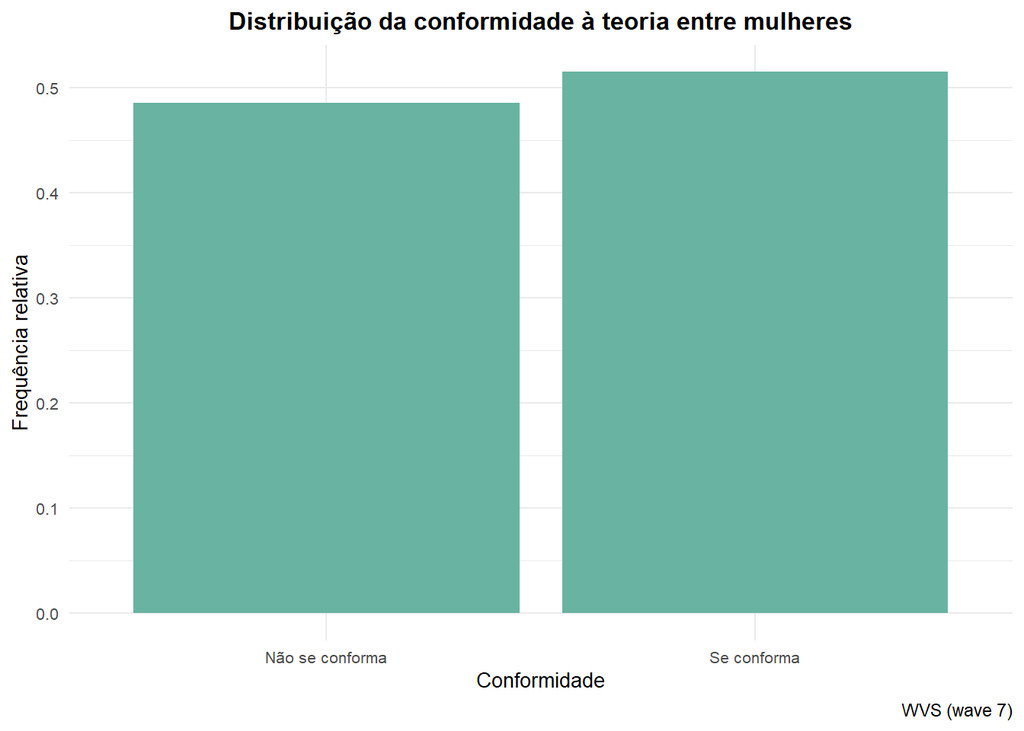

```r
svy_mulheres %>%
  ggsurvey() +
  geom_bar(aes(x = conformity, y= ..count.. / sum(..count..)), fill = '#69b3a2') +
  theme_minimal() +
  labs(x = 'Conformidade',
       y = 'Frequência relativa',
       title = 'Distribuição da conformidade à teoria entre mulheres',
       caption = 'WVS (wave 7)') +
  theme(plot.title=element_text(size=12, face="bold", hjust = 0.5),
        legend.text=element_text(size=8),
        axis.text=element_text(size=8),
        axis.title = element_text(size = 10),
        legend.title = element_text(size = 10)) +
  scale_x_discrete(labels = c('Não se conforma', 'Se conforma'))
```

Opinião sobre bater em seus filhos

[figure not shown]

```r
svy_mulheres %>%
  ggsurvey() +
  geom_bar(aes(x = not_acceptable_beat_children, y= ..count.. / sum(..count..)), fill = '#69b3a2') +
  theme_minimal() +
  labs(x = 'É válido que os pais batam em seus filhos?',
       y = 'Frequência relativa',
       title = 'Distribuição de mulheres de acordo opinião sobre bater em crianças',
       caption = 'WVS (wave 7)') +
  theme(plot.title=element_text(size=12, face="bold", hjust = 0.5),
        legend.text=element_text(size=8),
        axis.text=element_text(size=8),
        axis.title = element_text(size = 10),
        legend.title = element_text(size = 10))+
  scale_x_discrete(labels = c('Não concorda ', 'Concorda'))
```

Distribuição da preocupação com a educação de seus filhos

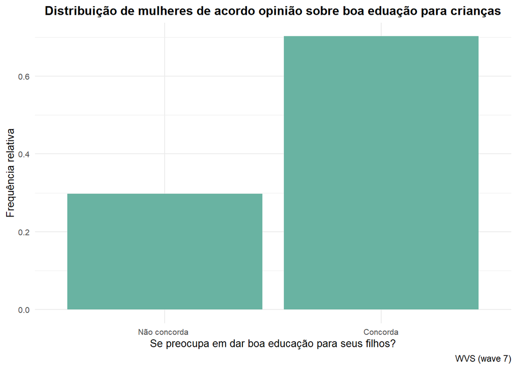

```r
svy_mulheres %>%
  ggsurvey() +
  geom_bar(aes(x = worries_education_children, y= ..count.. / sum(..count..)), fill = '#69b3a2') +
  theme_minimal() +
  labs(x = 'Se preocupa em dar boa educação para seus filhos?',
       y = 'Frequência relativa',
       title = 'Distribuição de mulheres de acordo opinião sobre boa eduação para crianças',
       caption = 'WVS (wave 7)') +
  theme(plot.title=element_text(size=12, face="bold", hjust = 0.5),
        legend.text=element_text(size=8),
        axis.text=element_text(size=8),
        axis.title = element_text(size = 10),
        legend.title = element_text(size = 10))+
  scale_x_discrete(labels = c('Não concorda ', 'Concorda'))
```

Distribuição do país entre mulheres

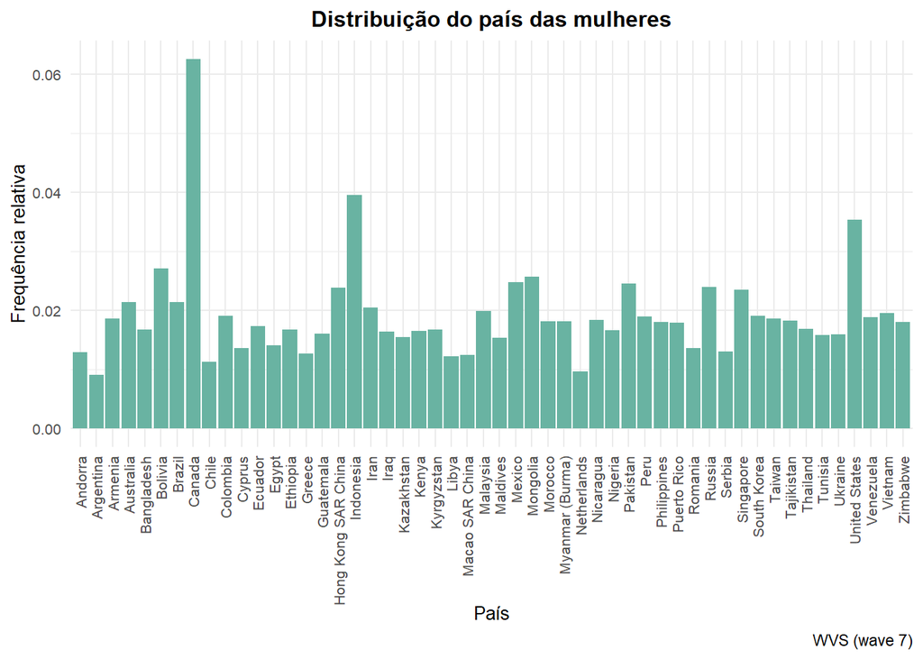

```r
svy_mulheres %>%
  ggsurvey() +
  geom_bar(aes(x = country, y= ..count.. / sum(..count..)), fill = '#69b3a2') +
  theme_minimal() +
  labs(x = 'País',
       y = 'Frequência relativa',
       title = 'Distribuição do país das mulheres',
       caption = 'WVS (wave 7)') +
  theme(plot.title=element_text(size=12, face="bold", hjust = 0.5),
        legend.text=element_text(size=8),
        axis.text=element_text(size=8),
        axis.title = element_text(size = 10),
        legend.title = element_text(size = 10),
        axis.text.x = element_text(angle = 90, vjust = 0.5, hjust=1))
```

Distribuição do sexo

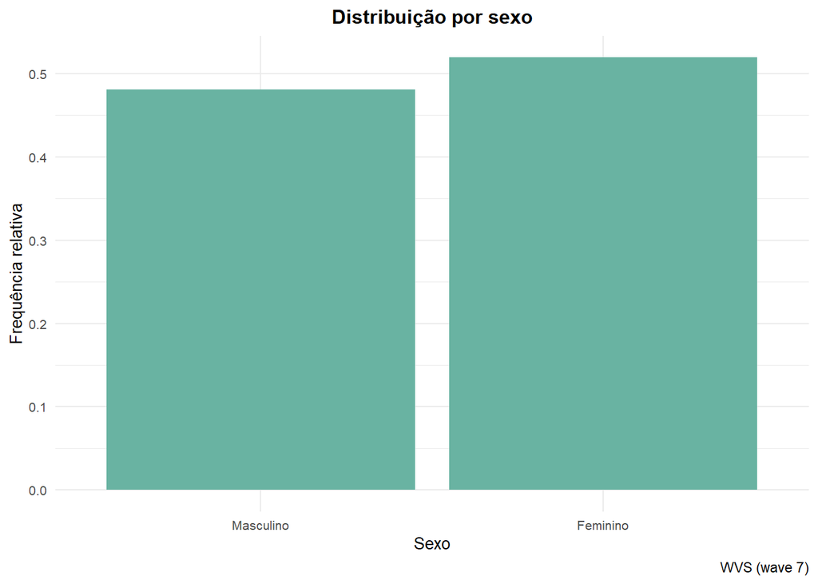

```r
svy %>%
  ggsurvey() +
  geom_bar(aes(x = sex, y= ..count.. / sum(..count..)), fill = '#69b3a2') +
  theme_minimal() +
  labs(x = 'Sexo',
       y = 'Frequência relativa',
       title = 'Distribuição por sexo',
       caption = 'WVS (wave 7)') +
  theme(plot.title=element_text(size=12, face="bold", hjust = 0.5),
        legend.text=element_text(size=8),
        axis.text=element_text(size=8),
        axis.title = element_text(size = 10),
        legend.title = element_text(size = 10))
```

Distribuição da faixa etária das mulheres

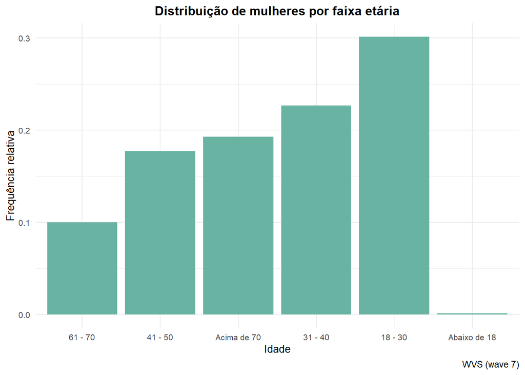

```r
svy_mulheres %>%
  ggsurvey() +
  geom_bar(aes(x = age, y= ..count.. / sum(..count..)), fill = '#69b3a2') +
  theme_minimal() +
  labs(x = 'Idade',
       y = 'Frequência relativa',
       title = 'Distribuição de mulheres por faixa etária',
       caption = 'WVS (wave 7)') +
  theme(plot.title=element_text(size=12, face="bold", hjust = 0.5),
        legend.text=element_text(size=8),
        axis.text=element_text(size=8),
        axis.title = element_text(size = 10),
        legend.title = element_text(size = 10))
```

Distribuição do estado civil entre mulheres

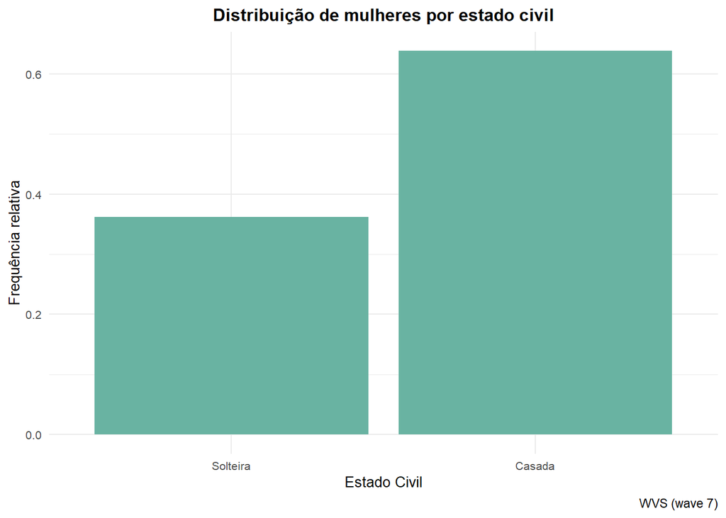

```r
svy_mulheres %>%
  ggsurvey() +
  geom_bar(aes(x = married, y= ..count.. / sum(..count..)), fill = '#69b3a2') +
  theme_minimal() +
  labs(x = 'Estado Civil',
       y = 'Frequência relativa',
       title = 'Distribuição de mulheres por estado civil',
       caption = 'WVS (wave 7)') +
  theme(plot.title=element_text(size=12, face="bold", hjust = 0.5),
        legend.text=element_text(size=8),
        axis.text=element_text(size=8),
        axis.title = element_text(size = 10),
        legend.title = element_text(size = 10)) +
    scale_x_discrete(labels = c('Solteira', 'Casada'))
```

Distribuição do número de filhos

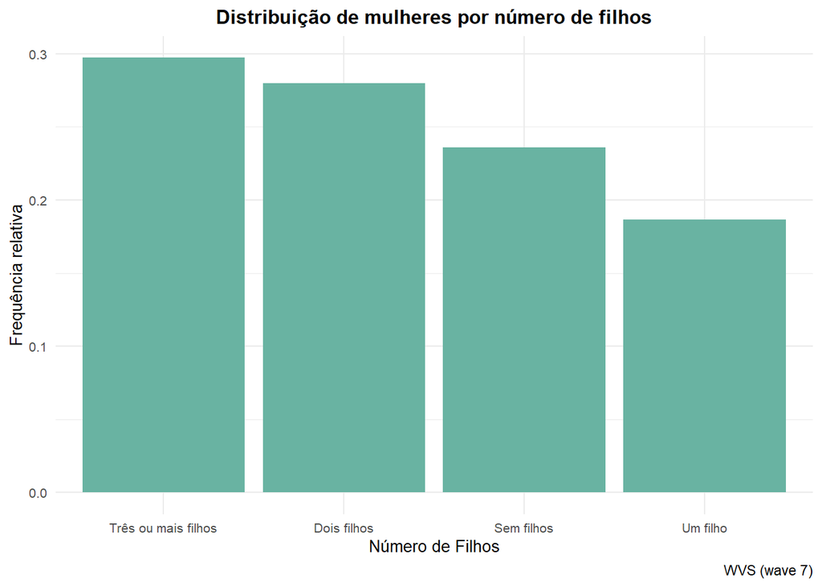

```r
svy_mulheres %>%
  ggsurvey() +
  geom_bar(aes(x = fct_infreq(number_children), y= ..count.. / sum(..count..)), fill = '#69b3a2') +
  theme_minimal() +
  labs(x = 'Número de Filhos',
       y = 'Frequência relativa',
       title = 'Distribuição de mulheres por número de filhos',
       caption = 'WVS (wave 7)') +
  theme(plot.title=element_text(size=12, face="bold", hjust = 0.5),
        legend.text=element_text(size=8),
        axis.text=element_text(size=8),
        axis.title = element_text(size = 10),
        legend.title = element_text(size = 10))
```

Distribuição da escolariadade entre as mulheres

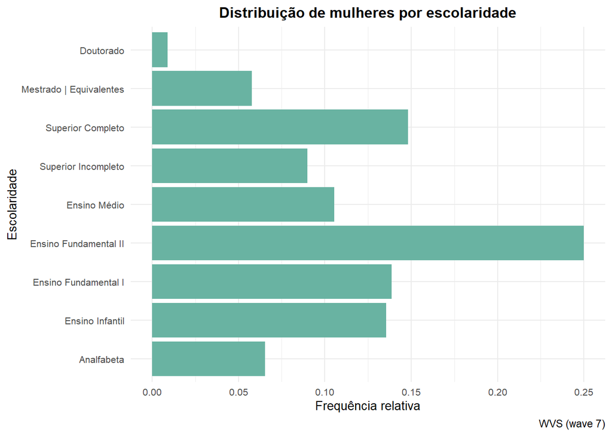

```r
svy_mulheres %>%
  ggsurvey() +
  geom_bar(aes(x = education_scale, y= ..count.. / sum(..count..)), fill = '#69b3a2') +
  theme_minimal() +
  labs(x = 'Escolaridade',
       y = 'Frequência relativa',
       title = 'Distribuição de mulheres por escolaridade',
       caption = 'WVS (wave 7)') +
  theme(plot.title=element_text(size=12, face="bold", hjust = 0.5),
        legend.text=element_text(size=8),
        axis.text=element_text(size=8),
        axis.title = element_text(size = 10),
        legend.title = element_text(size = 10))+
  scale_x_discrete(labels = c('Analfabeta', 'Ensino Infantil', 'Ensino Fundamental I',
                              'Ensino Fundamental II','Ensino Médio','Superior Incompleto',
                              'Superior Completo','Mestrado | Equivalentes','Doutorado')) +
  coord_flip()
```

Distribuição da escolaridade entre as mulheres

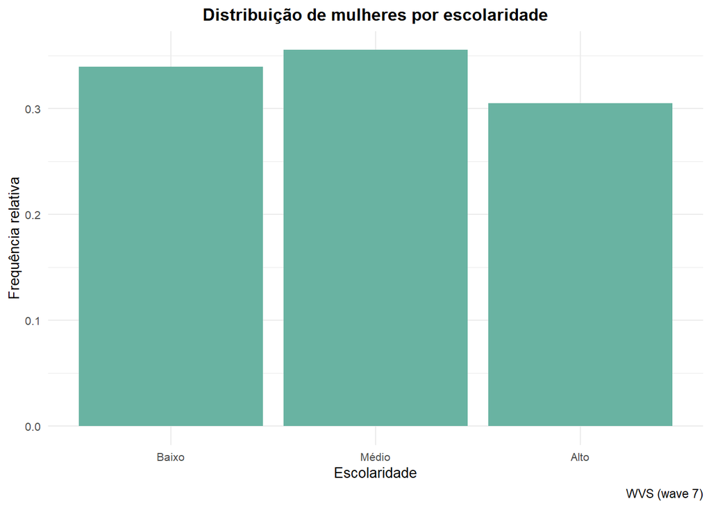

```r
svy_mulheres %>%
  ggsurvey() +
  geom_bar(aes(x = education_level, y= ..count.. / sum(..count..)), fill = '#69b3a2') +
  theme_minimal() +
  labs(x = 'Escolaridade',
       y = 'Frequência relativa',
       title = 'Distribuição de mulheres por escolaridade',
       caption = 'WVS (wave 7)') +
  theme(plot.title=element_text(size=12, face="bold", hjust = 0.5),
        legend.text=element_text(size=8),
        axis.text=element_text(size=8),
        axis.title = element_text(size = 10),
        legend.title = element_text(size = 10))
```

Distribuição do tipo de emprego entre mulheres

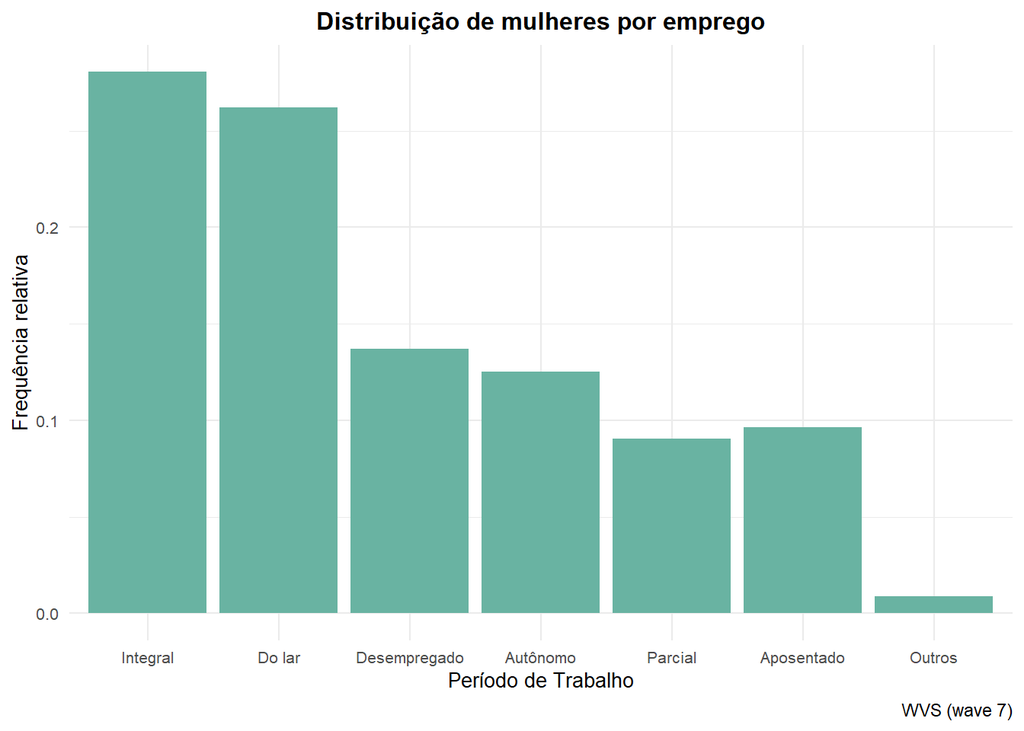

```r
svy_mulheres %>%
  ggsurvey() +
  geom_bar(aes(x = employment_status, y= ..count.. / sum(..count..)), fill = '#69b3a2') +
  theme_minimal() +
  labs(x = 'Período de Trabalho',
       y = 'Frequência relativa',
       title = 'Distribuição de mulheres por emprego',
       caption = 'WVS (wave 7)') +
  theme(plot.title=element_text(size=12, face="bold", hjust = 0.5),
        legend.text=element_text(size=8),
        axis.text=element_text(size=8),
        axis.title = element_text(size = 10),
        legend.title = element_text(size = 10))
```

Distribuição da renda entre mulheres

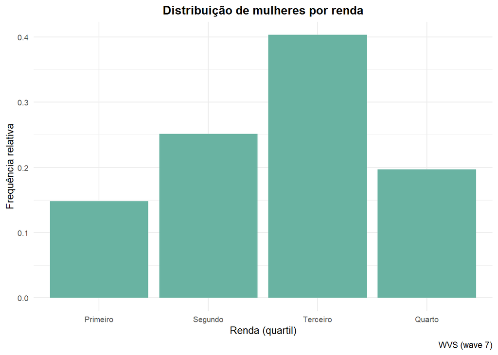

```r
svy_mulheres %>%
  ggsurvey() +
  geom_bar(aes(x = income_quantile, y= ..count.. / sum(..count..)), fill = '#69b3a2') +
  theme_minimal() +
  labs(x = 'Renda (quartil)',
       y = 'Frequência relativa',
       title = 'Distribuição de mulheres por renda',
       caption = 'WVS (wave 7)') +
  theme(plot.title=element_text(size=12, face="bold", hjust = 0.5),
        legend.text=element_text(size=8),
        axis.text=element_text(size=8),
        axis.title = element_text(size = 10),
        legend.title = element_text(size = 10))+
  scale_x_discrete(labels = c('Primeiro', 'Segundo', 'Terceiro','Quarto'))
```

Distribuição da renda entre mulheres

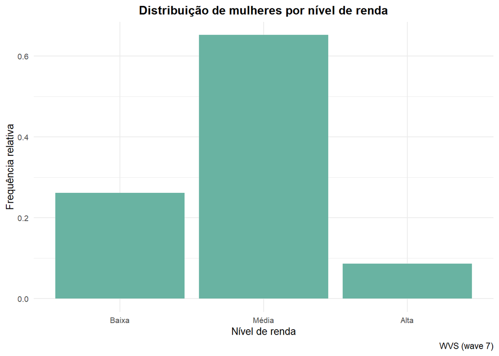

```r
svy_mulheres %>%
  ggsurvey() +
  geom_bar(aes(x = income_level, y= ..count.. / sum(..count..)), fill = '#69b3a2') +
  theme_minimal() +
  labs(x = 'Nível de renda',
       y = 'Frequência relativa',
       title = 'Distribuição de mulheres por nível de renda',
       caption = 'WVS (wave 7)') +
  theme(plot.title=element_text(size=12, face="bold", hjust = 0.5),
        legend.text=element_text(size=8),
        axis.text=element_text(size=8),
        axis.title = element_text(size = 10),
        legend.title = element_text(size = 10))+
  scale_x_discrete(labels = c('Baixa', 'Média', 'Alta'))
```

Distribuição da localização entre mulheres

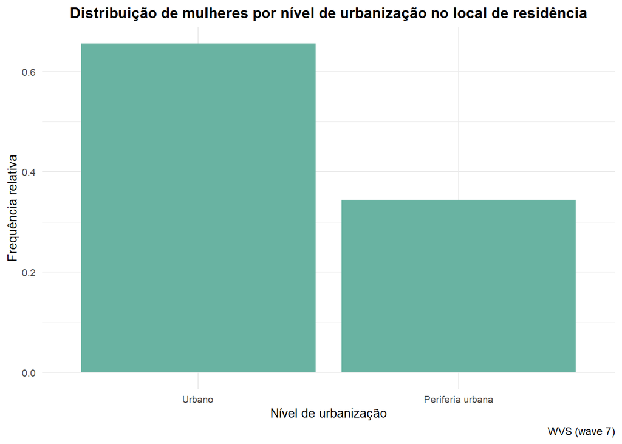

```r
svy_mulheres %>%
  ggsurvey() +
  geom_bar(aes(x = rural_area, y= ..count.. / sum(..count..)), fill = '#69b3a2') +
  theme_minimal() +
  labs(x = 'Nível de urbanização',
       y = 'Frequência relativa',
       title = 'Distribuição de mulheres por nível de urbanização no local de residência',
       caption = 'WVS (wave 7)') +
  theme(plot.title=element_text(size=12, face="bold", hjust = 0.5),
        legend.text=element_text(size=8),
        axis.text=element_text(size=8),
        axis.title = element_text(size = 10),
        legend.title = element_text(size = 10))+
  scale_x_discrete(labels = c('Urbano', 'Periferia urbana', 'rural'))
```

# Estimação

```r
modelo_mpl <- svyglm(as.numeric(happy) ~ conformity + age + income_quantile + number_children +
                       education_level  + employment_status,
                     design=svy_mulheres,
                     family=stats::gaussian(link="identity")) # modelo MPL

modelo_logit <- svyglm(happy ~ conformity +  age + income_quantile + number_children +
                         education_level  + employment_status,
                     design=svy_mulheres,
                     family=binomial(link="logit")) # modelo logit

modelo_probit <- svyglm(happy ~ conformity +  age + income_quantile + number_children +
                        education_level  + employment_status,
                      design=svy_mulheres,
                      family=binomial(link="probit")) # modelo probit
```

```r
margins_logit <- margins(modelo_logit, design=svy_mulheres) # efeitos marginais de logit

margins_probit <- margins(modelo_probit, design=svy_mulheres) # efeitos marginais de probit
```

```r
summary(modelo_logit) # tabela de coeficientes para logit
```

```
##
## Call:
## svyglm(formula = happy ~ conformity + age + income_quantile +
##     number_children + education_level + employment_status, design = svy_mulheres,
##     family = binomial(link = "logit"))
##
## Survey design:
## svydesign(id = ~1, weights = wvs_mulheres$sample_weight, data = wvs_mulheres)
##
## Coefficients:
##                                      Estimate Std. Error t value Pr(>|t|)
## (Intercept)                         1.1285103  0.0887630  12.714  < 2e-16 ***
## conformity1                         0.1850154  0.0363387   5.091 3.57e-07 ***
## age41 - 50                         -0.0001287  0.0720127  -0.002 0.998575
## ageAcima de 70                     -0.1046883  0.0653229  -1.603 0.109026
## age31 - 40                         -0.0275042  0.0706108  -0.390 0.696895
## age18 - 30                          0.1742633  0.0745247   2.338 0.019376 *
## ageAbaixo de 18                     0.1686613  0.3901417   0.432 0.665521
## income_quantile2                    0.3717618  0.0504790   7.365 1.82e-13 ***
## income_quantile3                    0.8666948  0.0496456  17.458  < 2e-16 ***
## income_quantile4                    1.1395230  0.0616498  18.484  < 2e-16 ***
## number_childrenTrês ou mais filhos -0.0911311  0.0449794  -2.026 0.042766 *
## number_childrenUm filho            -0.1164215  0.0524748  -2.219 0.026519 *
## number_childrenSem filhos          -0.2203524  0.0574379  -3.836 0.000125 ***
## education_levelMédio                0.1511599  0.0435607   3.470 0.000521 ***
## education_levelAlto                 0.2867379  0.0501629   5.716 1.10e-08 ***
## employment_statusDo lar            -0.0513771  0.0522199  -0.984 0.325192
## employment_statusDesempregado      -0.3205905  0.0603926  -5.308 1.11e-07 ***
## employment_statusAutônomo          -0.1559041  0.0596601  -2.613 0.008974 **
## employment_statusParcial           -0.0858247  0.0793322  -1.082 0.279332
## employment_statusAposentado        -0.2834837  0.0708199  -4.003 6.27e-05 ***
## employment_statusOutros            -0.4872046  0.1751482  -2.782 0.005411 **
## ---
## Signif. codes:  0 '***' 0.001 '**' 0.01 '*' 0.05 '.' 0.1 ' ' 1
##
## (Dispersion parameter for binomial family taken to be 1.003731)
##
## Number of Fisher Scoring iterations: 5
```

```r
summary(margins_logit) # tabela de efeitos marginais para logit
```

```
##                              factor     AME     SE       z      p   lower
##                          age18 - 30  0.0203 0.0089  2.2879 0.0221  0.0027
##                          age31 - 40 -0.0034 0.0088 -0.3910 0.6958 -0.0205
##                          age41 - 50 -0.0000 0.0089 -0.0018 0.9986 -0.0174
##                     ageAbaixo de 18  0.0197 0.0430  0.4570 0.6477 -0.0648
##                      ageAcima de 70 -0.0134 0.0082 -1.6254 0.1041 -0.0294
##                         conformity1  0.0225 0.0044  5.0796 0.0000  0.0136
##                 education_levelAlto  0.0346 0.0061  5.7180 0.0000  0.0226
##                education_levelMédio  0.0191 0.0055  3.4493 0.0006  0.0081
##         employment_statusAposentado -0.0349 0.0091 -3.8304 0.0001 -0.0525
##           employment_statusAutônomo -0.0184 0.0071 -2.5776 0.0099 -0.0322
##       employment_statusDesempregado -0.0400 0.0078 -5.1315 0.0000 -0.0550
##             employment_statusDo lar -0.0058 0.0059 -0.9846 0.3248 -0.0174
##             employment_statusOutros -0.0642 0.0264 -2.4278 0.0152 -0.1156
##            employment_statusParcial -0.0099 0.0093 -1.0623 0.2881 -0.0280
##                    income_quantile2  0.0604 0.0085  7.1353 0.0000  0.0436
##                    income_quantile3  0.1215 0.0078 15.5070 0.0000  0.1056
##                    income_quantile4  0.1468 0.0082 17.7966 0.0000  0.1299
##           number_childrenSem filhos -0.0269 0.0071 -3.7671 0.0002 -0.0407
##  number_childrenTrês ou mais filhos -0.0106 0.0053 -2.0271 0.0427 -0.0209
##             number_childrenUm filho -0.0137 0.0062 -2.2015 0.0277 -0.0258
##    upper
##   0.0375
##   0.0138
##   0.0174
##   0.1038
##   0.0029
##   0.0310
##   0.0463
##   0.0298
##  -0.0168
##  -0.0043
##  -0.0244
##   0.0058
##  -0.0120
##   0.0084
##   0.0768
##   0.1363
##   0.1622
##  -0.0127
##  -0.0003
##  -0.0014
```

```r
summary(modelo_probit) # tabela de coeficientes para probit
```

```
##
## Call:
## svyglm(formula = happy ~ conformity + age + income_quantile +
##     number_children + education_level + employment_status, design = svy_mulheres,
##     family = binomial(link = "probit"))
##
## Survey design:
## svydesign(id = ~1, weights = wvs_mulheres$sample_weight, data = wvs_mulheres)
##
## Coefficients:
##                                     Estimate Std. Error t value Pr(>|t|)
## (Intercept)                         0.689126   0.049340  13.967  < 2e-16 ***
## conformity1                         0.099112   0.019777   5.011 5.43e-07 ***
## age41 - 50                          0.002251   0.039694   0.057 0.954780
## ageAcima de 70                     -0.055377   0.036316  -1.525 0.127302
## age31 - 40                         -0.015060   0.038948  -0.387 0.699007
## age18 - 30                          0.090316   0.040837   2.212 0.027000 *
## ageAbaixo de 18                     0.077872   0.217434   0.358 0.720239
## income_quantile2                    0.214720   0.029126   7.372 1.72e-13 ***
## income_quantile3                    0.483342   0.028048  17.233  < 2e-16 ***
## income_quantile4                    0.622558   0.033352  18.666  < 2e-16 ***
## number_childrenTrês ou mais filhos -0.052609   0.024482  -2.149 0.031654 *
## number_childrenUm filho            -0.063839   0.028347  -2.252 0.024323 *
## number_childrenSem filhos          -0.117483   0.031092  -3.779 0.000158 ***
## education_levelMédio                0.083919   0.023856   3.518 0.000436 ***
## education_levelAlto                 0.155718   0.027026   5.762 8.39e-09 ***
## employment_statusDo lar            -0.025510   0.028044  -0.910 0.363010
## employment_statusDesempregado      -0.172367   0.032924  -5.235 1.66e-07 ***
## employment_statusAutônomo          -0.083661   0.032299  -2.590 0.009596 **
## employment_statusParcial           -0.041835   0.041840  -1.000 0.317377
## employment_statusAposentado        -0.148722   0.039113  -3.802 0.000144 ***
## employment_statusOutros            -0.267504   0.100104  -2.672 0.007538 **
## ---
## Signif. codes:  0 '***' 0.001 '**' 0.01 '*' 0.05 '.' 0.1 ' ' 1
##
## (Dispersion parameter for binomial family taken to be 1.003628)
##
## Number of Fisher Scoring iterations: 4
```

```r
summary(margins_probit) # tabela de efeitos marginais para probit
```

```
##                              factor     AME     SE       z      p   lower
##                          age18 - 30  0.0194 0.0089  2.1715 0.0299  0.0017
##                          age31 - 40 -0.0034 0.0088 -0.3880 0.6981 -0.0206
##                          age41 - 50  0.0005 0.0089  0.0567 0.9548 -0.0170
##                     ageAbaixo de 18  0.0168 0.0452  0.3725 0.7095 -0.0718
##                      ageAcima de 70 -0.0128 0.0083 -1.5425 0.1230 -0.0290
##                         conformity1  0.0220 0.0044  5.0034 0.0000  0.0132
##                 education_levelAlto  0.0345 0.0060  5.7507 0.0000  0.0226
##                education_levelMédio  0.0193 0.0055  3.4984 0.0005  0.0084
##         employment_statusAposentado -0.0334 0.0091 -3.6639 0.0002 -0.0511
##           employment_statusAutônomo -0.0182 0.0071 -2.5585 0.0105 -0.0320
##       employment_statusDesempregado -0.0392 0.0077 -5.0817 0.0000 -0.0541
##             employment_statusDo lar -0.0054 0.0059 -0.9099 0.3629 -0.0169
##             employment_statusOutros -0.0637 0.0267 -2.3888 0.0169 -0.1157
##            employment_statusParcial -0.0089 0.0090 -0.9865 0.3239 -0.0265
##                    income_quantile2  0.0609 0.0085  7.1772 0.0000  0.0441
##                    income_quantile3  0.1219 0.0078 15.5451 0.0000  0.1061
##                    income_quantile4  0.1468 0.0083 17.7977 0.0000  0.1301
##           number_childrenSem filhos -0.0261 0.0070 -3.7256 0.0002 -0.0397
##  number_childrenTrês ou mais filhos -0.0113 0.0053 -2.1483 0.0317 -0.0216
##             number_childrenUm filho -0.0138 0.0062 -2.2377 0.0252 -0.0258
##    upper
##   0.0367
##   0.0138
##   0.0180
##   0.1052
##   0.0036
##   0.0305
##   0.0461
##   0.0300
##  -0.0154
##  -0.0042
##  -0.0239
##   0.0062
##  -0.0111
##   0.0088
##   0.0774
##   0.1368
##   0.1625
##  -0.0122
##  -0.0009
##  -0.0016
```

```r
odds_logit <- exp(cbind(coef(modelo_logit),confint(modelo_logit))) # odds para o modelo logit
stargazer(odds_logit, summary = FALSE)
```

```
##
## % Table created by stargazer v.5.2.3 by Marek Hlavac, Social Policy Institute. E-mail: marek.hlavac at gmail.com
## % Date and time: seg, set 19, 2022 - 09:51:44
## \begin{table}[!htbp] \centering
##   \caption{}
##   \label{}
## \begin{tabular}{@{\extracolsep{5pt}} cccc}
## \\[-1.8ex]\hline
## \hline \\[-1.8ex]
##  & .1 & 2.5 \% & 97.5 \% \\
## \hline \\[-1.8ex]
## (Intercept) & $3.091$ & $2.597$ & $3.678$ \\
## conformity1 & $1.203$ & $1.121$ & $1.292$ \\
## age41 - 50 & $1.000$ & $0.868$ & $1.151$ \\
## ageAcima de 70 & $0.901$ & $0.792$ & $1.024$ \\
## age31 - 40 & $0.973$ & $0.847$ & $1.117$ \\
## age18 - 30 & $1.190$ & $1.029$ & $1.378$ \\
## ageAbaixo de 18 & $1.184$ & $0.551$ & $2.543$ \\
## income\_quantile2 & $1.450$ & $1.314$ & $1.601$ \\
## income\_quantile3 & $2.379$ & $2.158$ & $2.622$ \\
## income\_quantile4 & $3.125$ & $2.770$ & $3.527$ \\
## number\_childrenTrês ou mais filhos & $0.913$ & $0.836$ & $0.997$ \\
## number\_childrenUm filho & $0.890$ & $0.803$ & $0.987$ \\
## number\_childrenSem filhos & $0.802$ & $0.717$ & $0.898$ \\
## education\_levelMédio & $1.163$ & $1.068$ & $1.267$ \\
## education\_levelAlto & $1.332$ & $1.207$ & $1.470$ \\
## employment\_statusDo lar & $0.950$ & $0.858$ & $1.052$ \\
## employment\_statusDesempregado & $0.726$ & $0.645$ & $0.817$ \\
## employment\_statusAutônomo & $0.856$ & $0.761$ & $0.962$ \\
## employment\_statusParcial & $0.918$ & $0.786$ & $1.072$ \\
## employment\_statusAposentado & $0.753$ & $0.656$ & $0.865$ \\
## employment\_statusOutros & $0.614$ & $0.436$ & $0.866$ \\
## \hline \\[-1.8ex]
## \end{tabular}
## \end{table}
```

```r
stargazer(modelo_mpl, modelo_logit, modelo_probit) # tabela de coeficientes dos três modelos
```

```
##
## % Table created by stargazer v.5.2.3 by Marek Hlavac, Social Policy Institute. E-mail: marek.hlavac at gmail.com
## % Date and time: seg, set 19, 2022 - 09:51:46
## \begin{table}[!htbp] \centering
##   \caption{}
##   \label{}
## \begin{tabular}{@{\extracolsep{5pt}}lccc}
## \\[-1.8ex]\hline
## \hline \\[-1.8ex]
##  & \multicolumn{3}{c}{\textit{Dependent variable:}} \\
## \cline{2-4}
## \\[-1.8ex] & as.numeric(happy) & \multicolumn{2}{c}{happy} \\
## \\[-1.8ex] & \textit{survey-weighted} & \textit{survey-weighted} & \textit{survey-weighted} \\
##  & \textit{normal} & \textit{logistic} & \textit{probit} \\
## \\[-1.8ex] & (1) & (2) & (3)\\
## \hline \\[-1.8ex]
##  conformity1 & 0.023$^{***}$ & 0.185$^{***}$ & 0.099$^{***}$ \\
##   & (0.004) & (0.036) & (0.020) \\
##   & & & \\
##  age41 - 50 & $-$0.001 & $-$0.0001 & 0.002 \\
##   & (0.009) & (0.072) & (0.040) \\
##   & & & \\
##  ageAcima de 70 & $-$0.014 & $-$0.105 & $-$0.055 \\
##   & (0.009) & (0.065) & (0.036) \\
##   & & & \\
##  age31 - 40 & $-$0.004 & $-$0.028 & $-$0.015 \\
##   & (0.009) & (0.071) & (0.039) \\
##   & & & \\
##  age18 - 30 & 0.019$^{**}$ & 0.174$^{**}$ & 0.090$^{**}$ \\
##   & (0.010) & (0.075) & (0.041) \\
##   & & & \\
##  ageAbaixo de 18 & 0.020 & 0.169 & 0.078 \\
##   & (0.054) & (0.390) & (0.217) \\
##   & & & \\
##  income\_quantile2 & 0.064$^{***}$ & 0.372$^{***}$ & 0.215$^{***}$ \\
##   & (0.009) & (0.050) & (0.029) \\
##   & & & \\
##  income\_quantile3 & 0.126$^{***}$ & 0.867$^{***}$ & 0.483$^{***}$ \\
##   & (0.008) & (0.050) & (0.028) \\
##   & & & \\
```

[output cut: 33 more lines]

```
##  employment\_statusOutros & $-$0.070$^{**}$ & $-$0.487$^{***}$ & $-$0.268$^{***}$ \\
##   & (0.029) & (0.175) & (0.100) \\
##   & & & \\
##  Constant & 1.751$^{***}$ & 1.129$^{***}$ & 0.689$^{***}$ \\
##   & (0.013) & (0.089) & (0.049) \\
##   & & & \\
## \hline \\[-1.8ex]
## Observations & 33,331 & 33,331 & 33,331 \\
## Log Likelihood & $-$13,283.630 & $-$13,652.380 & $-$13,655.720 \\
## Akaike Inf. Crit. & 26,609.260 & 27,346.770 & 27,353.440 \\
## \hline
## \hline \\[-1.8ex]
## \textit{Note:}  & \multicolumn{3}{r}{$^{*}$p$<$0.1; $^{**}$p$<$0.05; $^{***}$p$<$0.01} \\
## \end{tabular}
## \end{table}
```

```r
stargazer(summary(margins_logit), summary = FALSE) # tabela de efeitos marginais do modelo logit
```

```
##
## % Table created by stargazer v.5.2.3 by Marek Hlavac, Social Policy Institute. E-mail: marek.hlavac at gmail.com
## % Date and time: seg, set 19, 2022 - 09:51:48
## \begin{table}[!htbp] \centering
##   \caption{}
##   \label{}
## \begin{tabular}{@{\extracolsep{5pt}} cccccccc}
## \\[-1.8ex]\hline
## \hline \\[-1.8ex]
##  & factor & AME & SE & z & p & lower & upper \\
## \hline \\[-1.8ex]
## 1 & age18 - 30 & $0.020$ & $0.009$ & $2.288$ & $0.022$ & $0.003$ & $0.037$ \\
## 2 & age31 - 40 & $$-$0.003$ & $0.009$ & $$-$0.391$ & $0.696$ & $$-$0.021$ & $0.014$ \\
## 3 & age41 - 50 & $$-$0.00002$ & $0.009$ & $$-$0.002$ & $0.999$ & $$-$0.017$ & $0.017$ \\
## 4 & ageAbaixo de 18 & $0.020$ & $0.043$ & $0.457$ & $0.648$ & $$-$0.065$ & $0.104$ \\
## 5 & ageAcima de 70 & $$-$0.013$ & $0.008$ & $$-$1.625$ & $0.104$ & $$-$0.029$ & $0.003$ \\
## 6 & conformity1 & $0.022$ & $0.004$ & $5.080$ & $0.00000$ & $0.014$ & $0.031$ \\
## 7 & education\_levelAlto & $0.035$ & $0.006$ & $5.718$ & $0$ & $0.023$ & $0.046$ \\
## 8 & education\_levelMédio & $0.019$ & $0.006$ & $3.449$ & $0.001$ & $0.008$ & $0.030$ \\
## 9 & employment\_statusAposentado & $$-$0.035$ & $0.009$ & $$-$3.830$ & $0.0001$ & $$-$0.053$ & $$-$0.017$ \\
## 10 & employment\_statusAutônomo & $$-$0.018$ & $0.007$ & $$-$2.578$ & $0.010$ & $$-$0.032$ & $$-$0.004$ \\
## 11 & employment\_statusDesempregado & $$-$0.040$ & $0.008$ & $$-$5.132$ & $0.00000$ & $$-$0.055$ & $$-$0.024$ \\
## 12 & employment\_statusDo lar & $$-$0.006$ & $0.006$ & $$-$0.985$ & $0.325$ & $$-$0.017$ & $0.006$ \\
## 13 & employment\_statusOutros & $$-$0.064$ & $0.026$ & $$-$2.428$ & $0.015$ & $$-$0.116$ & $$-$0.012$ \\
## 14 & employment\_statusParcial & $$-$0.010$ & $0.009$ & $$-$1.062$ & $0.288$ & $$-$0.028$ & $0.008$ \\
## 15 & income\_quantile2 & $0.060$ & $0.008$ & $7.135$ & $0$ & $0.044$ & $0.077$ \\
## 16 & income\_quantile3 & $0.121$ & $0.008$ & $15.507$ & $0$ & $0.106$ & $0.136$ \\
## 17 & income\_quantile4 & $0.147$ & $0.008$ & $17.797$ & $0$ & $0.130$ & $0.162$ \\
## 18 & number\_childrenSem filhos & $$-$0.027$ & $0.007$ & $$-$3.767$ & $0.0002$ & $$-$0.041$ & $$-$0.013$ \\
## 19 & number\_childrenTrês ou mais filhos & $$-$0.011$ & $0.005$ & $$-$2.027$ & $0.043$ & $$-$0.021$ & $$-$0.0003$ \\
## 20 & number\_childrenUm filho & $$-$0.014$ & $0.006$ & $$-$2.202$ & $0.028$ & $$-$0.026$ & $$-$0.001$ \\
## \hline \\[-1.8ex]
## \end{tabular}
## \end{table}
```

```r
stargazer(summary(margins_probit), summary = FALSE) # tabela de efeitos marginais do moelo probit
```

```
##
## % Table created by stargazer v.5.2.3 by Marek Hlavac, Social Policy Institute. E-mail: marek.hlavac at gmail.com
## % Date and time: seg, set 19, 2022 - 09:51:48
## \begin{table}[!htbp] \centering
##   \caption{}
##   \label{}
## \begin{tabular}{@{\extracolsep{5pt}} cccccccc}
## \\[-1.8ex]\hline
## \hline \\[-1.8ex]
##  & factor & AME & SE & z & p & lower & upper \\
## \hline \\[-1.8ex]
## 1 & age18 - 30 & $0.019$ & $0.009$ & $2.172$ & $0.030$ & $0.002$ & $0.037$ \\
## 2 & age31 - 40 & $$-$0.003$ & $0.009$ & $$-$0.388$ & $0.698$ & $$-$0.021$ & $0.014$ \\
## 3 & age41 - 50 & $0.001$ & $0.009$ & $0.057$ & $0.955$ & $$-$0.017$ & $0.018$ \\
## 4 & ageAbaixo de 18 & $0.017$ & $0.045$ & $0.372$ & $0.710$ & $$-$0.072$ & $0.105$ \\
## 5 & ageAcima de 70 & $$-$0.013$ & $0.008$ & $$-$1.542$ & $0.123$ & $$-$0.029$ & $0.004$ \\
## 6 & conformity1 & $0.022$ & $0.004$ & $5.003$ & $0.00000$ & $0.013$ & $0.030$ \\
## 7 & education\_levelAlto & $0.035$ & $0.006$ & $5.751$ & $0$ & $0.023$ & $0.046$ \\
## 8 & education\_levelMédio & $0.019$ & $0.006$ & $3.498$ & $0.0005$ & $0.008$ & $0.030$ \\
## 9 & employment\_statusAposentado & $$-$0.033$ & $0.009$ & $$-$3.664$ & $0.0002$ & $$-$0.051$ & $$-$0.015$ \\
## 10 & employment\_statusAutônomo & $$-$0.018$ & $0.007$ & $$-$2.558$ & $0.011$ & $$-$0.032$ & $$-$0.004$ \\
## 11 & employment\_statusDesempregado & $$-$0.039$ & $0.008$ & $$-$5.082$ & $0.00000$ & $$-$0.054$ & $$-$0.024$ \\
## 12 & employment\_statusDo lar & $$-$0.005$ & $0.006$ & $$-$0.910$ & $0.363$ & $$-$0.017$ & $0.006$ \\
## 13 & employment\_statusOutros & $$-$0.064$ & $0.027$ & $$-$2.389$ & $0.017$ & $$-$0.116$ & $$-$0.011$ \\
## 14 & employment\_statusParcial & $$-$0.009$ & $0.009$ & $$-$0.986$ & $0.324$ & $$-$0.027$ & $0.009$ \\
## 15 & income\_quantile2 & $0.061$ & $0.008$ & $7.177$ & $0$ & $0.044$ & $0.077$ \\
## 16 & income\_quantile3 & $0.122$ & $0.008$ & $15.545$ & $0$ & $0.106$ & $0.137$ \\
## 17 & income\_quantile4 & $0.147$ & $0.008$ & $17.798$ & $0$ & $0.130$ & $0.162$ \\
## 18 & number\_childrenSem filhos & $$-$0.026$ & $0.007$ & $$-$3.726$ & $0.0002$ & $$-$0.040$ & $$-$0.012$ \\
## 19 & number\_childrenTrês ou mais filhos & $$-$0.011$ & $0.005$ & $$-$2.148$ & $0.032$ & $$-$0.022$ & $$-$0.001$ \\
## 20 & number\_childrenUm filho & $$-$0.014$ & $0.006$ & $$-$2.238$ & $0.025$ & $$-$0.026$ & $$-$0.002$ \\
## \hline \\[-1.8ex]
## \end{tabular}
## \end{table}
```

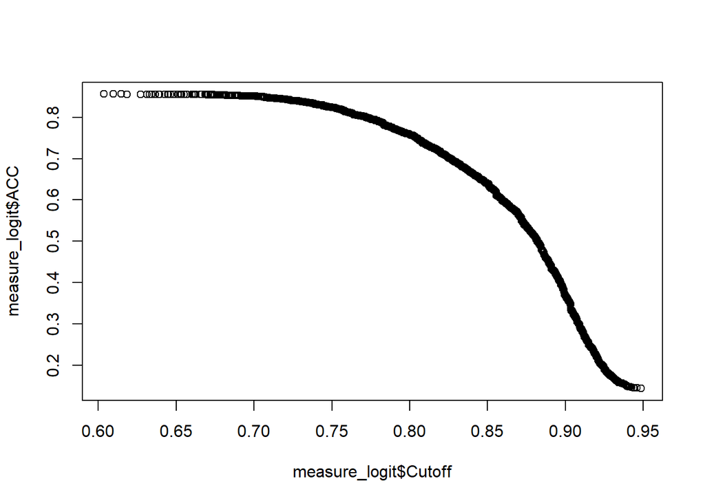

```r
roc_logit <- rocit(score = modelo_logit$fitted.values, class = modelo_logit$y) # obtendo a curva roc do modelo logit

measure_logit <- measureit(roc_logit, measure = c("ACC","SENS","SPEC")) # obtendo acurácia, sensibilidade e especificidade do modelo logit

#Acurácia total do modelo logit
plot(measure_logit$Cutoff,measure_logit$ACC)
```

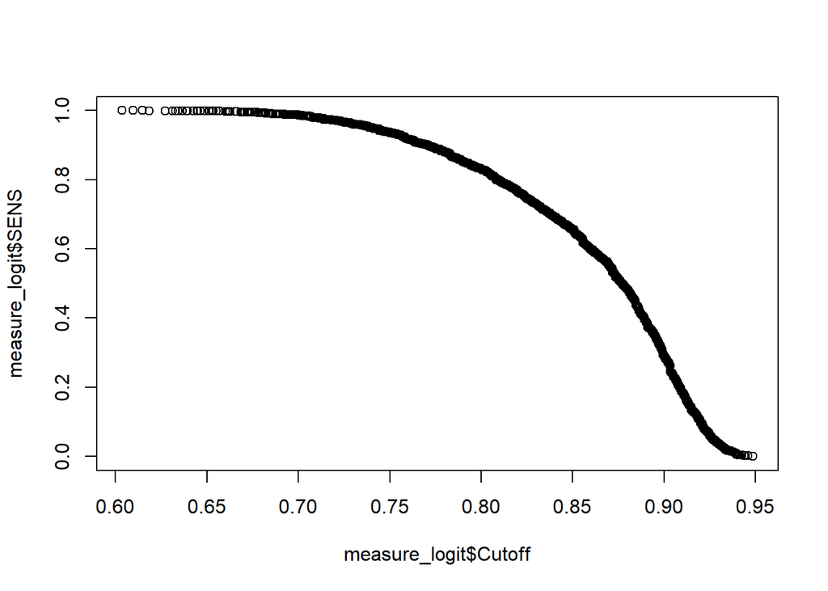

```r
#Focando especificamente na sensibilidade do modelo logit
plot(measure_logit$Cutoff,measure_logit$SENS)
```

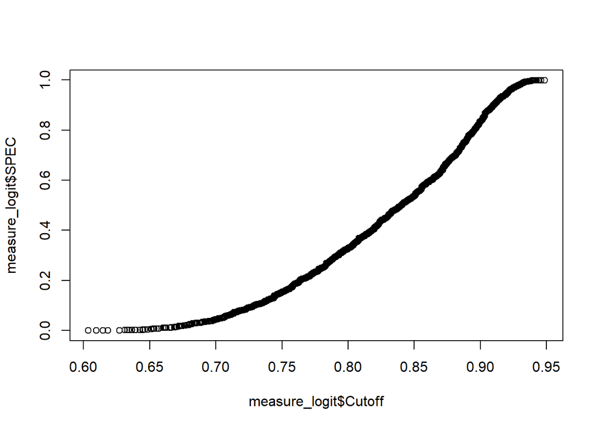

```r
#Focando na especificidade do modelo logit
plot(measure_logit$Cutoff,measure_logit$SPEC)
```

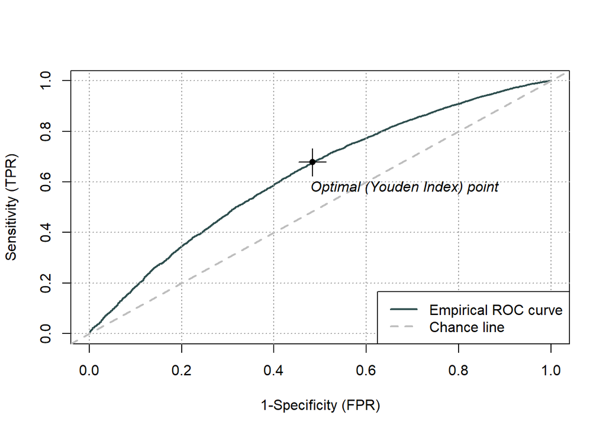

```r
plot(roc_logit) # plotando a curva roc do modelo logit
```

*Pearson or Hosmer-Lemeshow goodness-of-fit test:*

H0: Modelo bem especificado  
HA: Modelo mal especificado

```r
hoslem.test(modelo_logit$y,fitted(modelo_logit),g=10)
```

```
##
##  Hosmer and Lemeshow goodness of fit (GOF) test
##
## data:  modelo_logit$y, fitted(modelo_logit)
## X-squared = 10.977, df = 8, p-value = 0.203
```

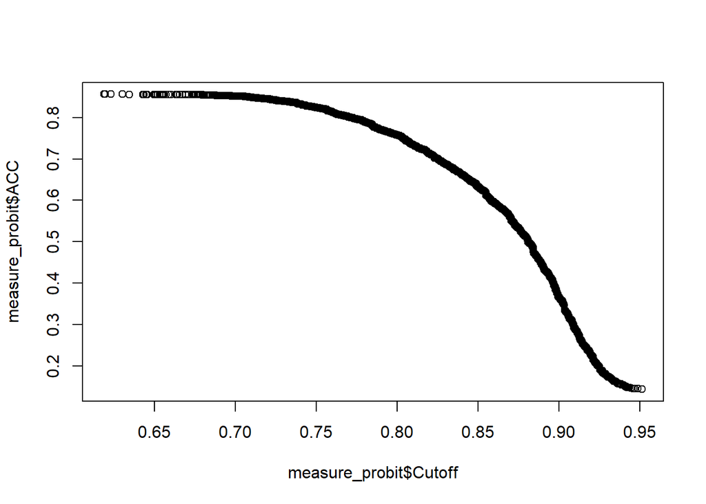

```r
roc_probit <- rocit(score = modelo_probit$fitted.values, class = modelo_probit$y) # obtendo a curva roc do modelo probit

measure_probit <- measureit(roc_probit, measure = c("ACC","SENS","SPEC")) # obtendo acurácia, sensibilidade e especificidade do modelo probit

#Acurácia total do modelo probit
plot(measure_probit$Cutoff,measure_probit$ACC)
```

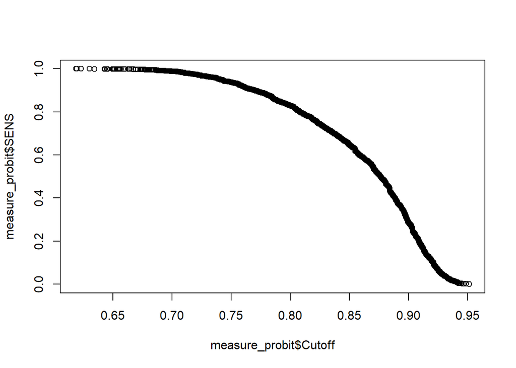

```r
#Focando especificamente na sensibilidade do modelo probit
plot(measure_probit$Cutoff,measure_probit$SENS)
```

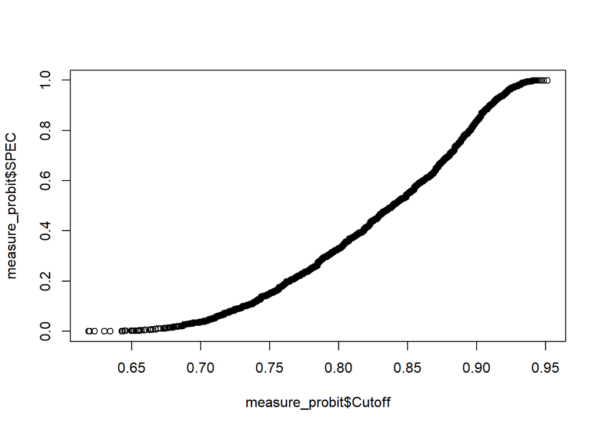

```r
#Focando na especificidade do modelo probit
plot(measure_probit$Cutoff,measure_probit$SPEC)
```

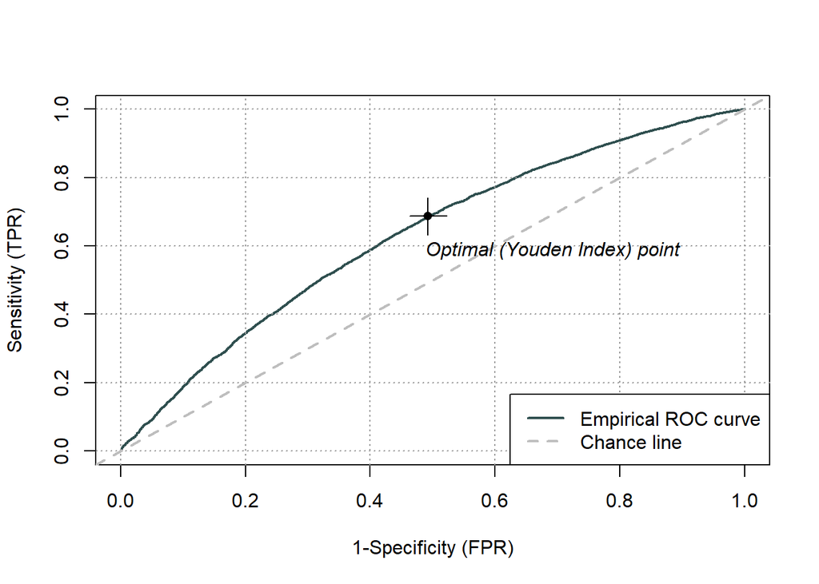

```r
plot(roc_probit) # plotando a curva roc do modelo probit
```

*Pearson or Hosmer-Lemeshow goodness-of-fit test:*

H0: Modelo bem especificado  
HA: Modelo mal especificado

```r
hoslem.test(modelo_probit$y,fitted(modelo_probit),g=10)
```

```
##
##  Hosmer and Lemeshow goodness of fit (GOF) test
##
## data:  modelo_probit$y, fitted(modelo_probit)
## X-squared = 12.403, df = 8, p-value = 0.1341
```